# Project 2

Author

Hector Gavilanes

```r
library(tidyverse)
library(gsheet)
library(formattable)
library(DescTools) # perform Dunnett, Levene Test
library(pgirmess) # perform Kruskal-Wallis Post-hoc
library(ggpubr) # interaction plot
library(ggstatsplot) # boxplot
library(ISLR)
```

**1. Consider a sample of data from the [Jackson Heart Study](https://www.jacksonheartstudy.org/). In this problem, we will be examining body mass index (*BMI*; kg/m<sup>2</sup>) as a function of health as categorized by physical activity (*PA3cat*; Ideal Health, Intermediate Health, and Poor Health).**

```r
# clear environment
rm(list = ls())
# import data
data <- as_tibble(gsheet2tbl("https://docs.google.com/spreadsheets/d/1H3TP-2SBMGleriJLESOe1cdCjtSj2F76bUh5iBqC8tI/edit#gid=2142000894"))
# clean data
clean_data <- data %>%
  select(BMI, BMI3cat) %>%
  drop_na()

# ---CUSTOM COLORS---
custom_green_dark = "#71CA97"
custom_green_light = "#DeF7E9"
custom_gray = "#3D3D3D"
custom_orange = "#FC7307"
custom_purple = "#5A18C9"
# custom_tan_light = "#F7E3D4"
custom_red_light = "#F7D0C7"
custom_red_dark = "#F1917C"
# custom_density_hue = c(custom_purple,custom_orange)
# ---FUNCTIONS---
# f00 - Change default table format
change_table_format <- function(data_table){
  # local variables
  first_column <- data_table[1]
  dataframe_length <- NCOL(data_table)
  # format
  formattable(data_table, align = c("l",rep("c", dataframe_length - 1)),
              list(first_column = formatter("span", style = ~ style(color = custom_gray, font.weight = "bold")),
              area(row = 1, col = 2:dataframe_length) ~ color_tile(custom_green_light, custom_green_dark),
              area(row = 3, col = 2:dataframe_length) ~ color_tile(custom_red_light, custom_red_dark)
              )#/end list
              )#/end formattable
}
# f01 - get custom summary statistics
# !! sym() creates a symbol from a string
get_custom_summary <- function(data_table, category, values){
  summary <- data_table %>%
    group_by(!! sym(category)) %>%
    summarise(Avg = mean(!! sym(values)),
              Median = median(!! sym(values)),
              SD = sd(!! sym(values)),
              Min = min(!! sym(values)),
              Max = max(!! sym(values)),
              IQRange = IQR(!! sym(values))
              )
    return(summary)
}
```

**a. Find the appropriate summary statistics to summarize the data.**

```r
change_table_format(get_custom_summary(clean_data, "BMI3cat", "BMI"))
```

| BMI3cat | Avg | Median | SD | Min | Max | IQRange |
| --- | --- | --- | --- | --- | --- | --- |
| Ideal Health | 22.78914 | 23.34 | 1.798843 | 18.53 | 25.00 | 2.42 |
| Intermediate Health | 27.60544 | 27.62 | 1.413412 | 25.00 | 29.99 | 2.53 |
| Poor Health | 36.63521 | 35.06 | 5.845224 | 30.00 | 59.57 | 6.68 |

**b. Use ANOVA to determine if there is a difference in BMI between the three levels of health as categorized by physical activity. Test at the $\alpha=0.05$ level.**

```r
# One-way ANOVA
# Null Hypothesis:
# - H0: All means of observations grouped by BMI category are the same
# - H1: At least one category is different

h1 <- aov(clean_data$BMI ~ clean_data$BMI3cat)
summary(h1)
```

```
                     Df Sum Sq Mean Sq F value Pr(>F)
clean_data$BMI3cat    2  76958   38479    1966 <2e-16 ***
Residuals          2646  51780      20
---
Signif. codes:  0 '***' 0.001 '**' 0.01 '*' 0.05 '.' 0.1 ' ' 1
```

### Hypothesis

- $H_0$: $\mu Ideal = \mu Intermediate\ = \mu Poor$
- $H_1$: at least one is different

### Test Statistic

- $F_0 = 1966$

### p-Value

- $p < 0.001$

## Conclusion

Reject $H_0$ at the $\alpha$=0.05 level. There is sufficient evidence to suggest that there is a difference in BMI between the three levels of health.

**c. Use the Kruskal-Wallis to determine if there is a difference in BMI between the three levels of health as categorized by physical activity (*PA3cat*; Ideal Health, Intermediate Health, and Poor Health). Test at the $\alpha=0.05$ level.**

```r
kruskal.test(clean_data$BMI ~ clean_data$BMI3cat)
```

```
    Kruskal-Wallis rank sum test

data:  clean_data$BMI by clean_data$BMI3cat
Kruskal-Wallis chi-squared = 2129.4, df = 2, p-value < 2.2e-16
```

### Hypothesis: Kruskal-Wallis

- $H_0$: $M_{Ideal} = M_{Intermediate} = M_{Poor}$
- $H_1$: at least one group is different

### Test Statistic

- $H = 2129.4$

### p-Value

- $p < 0.001$

## Conclusion

Reject $H_0$ at the $\alpha$=0.05 level. There is sufficient evidence to suggest that there is a difference in BMI between the three levels of health.

**d. State/explain the ANOVA assumptions and assess them. Remember to state your conclusion (that you either meet the ANOVA assumptions or you do not).**

We are unwilling to assume normality because we have found the assumption of normality invalid in diagnostic checks. We have performed the following ANOVA assumptions:

1. Independence – the observations in each group need to be independent of each other. The data provided meets this requirement.
2. Normality – the dependent variable should be approximately normally distributed for each combination of the groups. However, the residuals are not normally distributed; thus, we cannot assume normality.

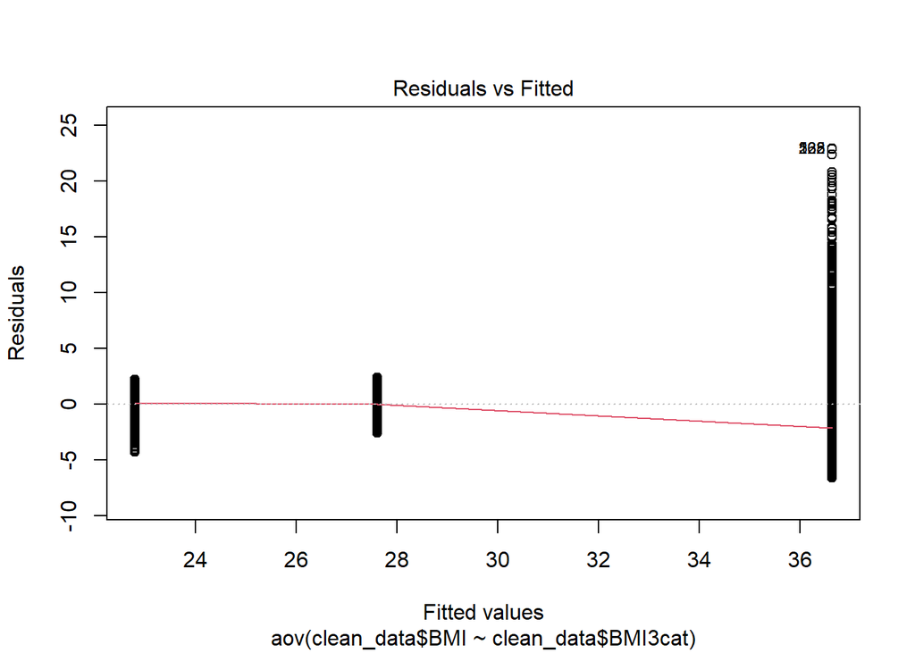

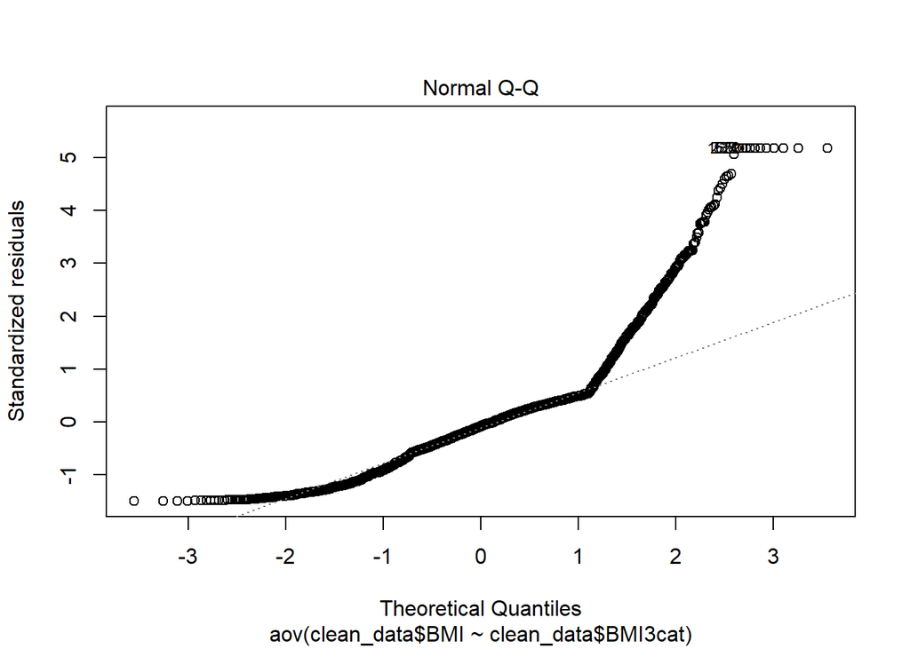

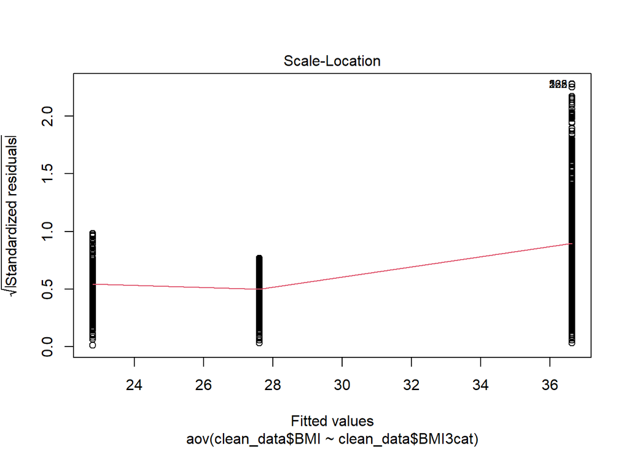

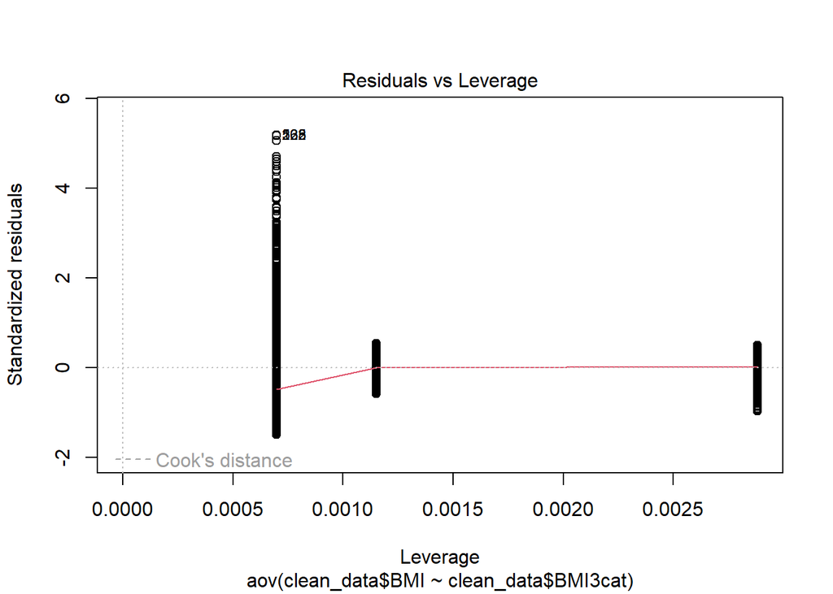

```r
# 2. Normality check
plot(h1)
```

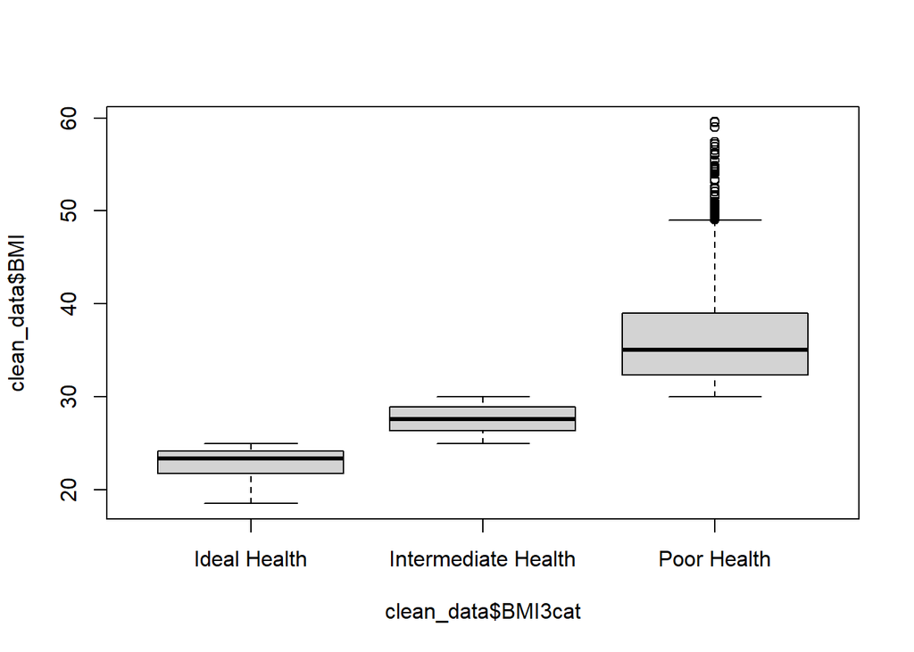

```r
boxplot(clean_data$BMI ~ clean_data$BMI3cat)
```

3. Equal Variance - the variances for each group are equal or approximately equal. Since the p-value < 0.001 which is lower than our 0.05 level of significance, we cannot assume equality of variances.

```r
# 3. Levene's test for equality of variance
LeveneTest(clean_data$BMI ~ clean_data$BMI3cat,
           exact = FALSE)
```

```
Levene's Test for Homogeneity of Variance (center = median: FALSE)
        Df F value    Pr(>F)
group    2  283.73 < 2.2e-16 ***
      2646
---
Signif. codes:  0 '***' 0.001 '**' 0.01 '*' 0.05 '.' 0.1 ' ' 1
```

**e. Based on your responses in part (d), which test’s result are you going to present to the lead scientist at the JHS? (Hint: you will pick either (b) or (c)).**

Nonparametric test, Kruskal-Wallis, in this case.

**f. Perform the appropriate posthoc test to determine pairwise differences between the three groups. Test at the $\alpha=0.05$ level.**

```r
# Kruskal-Wallis post-hoc
kruskalmc(clean_data$BMI ~ clean_data$BMI3cat)
```

```
Multiple comparison test after Kruskal-Wallis
p.value: 0.05
Comparisons
                                  obs.dif critical.dif difference
Ideal Health-Intermediate Health  607.998    116.27489       TRUE
Ideal Health-Poor Health         1758.999    109.55090       TRUE
Intermediate Health-Poor Health  1151.001     78.72514       TRUE
```

```r
# Multiple pairwise-comparison between groups
pairwise.wilcox.test(clean_data$BMI, clean_data$BMI3cat,
                     p.adjust.method = "bonferroni",
                     exact = FALSE)
```

```
    Pairwise comparisons using Wilcoxon rank sum test with continuity correction

data:  clean_data$BMI and clean_data$BMI3cat

                    Ideal Health Intermediate Health
Intermediate Health <2e-16       -
Poor Health         <2e-16       <2e-16

P value adjustment method: bonferroni
```

```r
# nonparametric DunnTest
DunnTest(clean_data$BMI ~ clean_data$BMI3cat)
```

```
 Dunn's test of multiple comparisons using rank sums : holm

                                 mean.rank.diff   pval
Intermediate Health-Ideal Health        607.998 <2e-16 ***
Poor Health-Ideal Health               1758.999 <2e-16 ***
Poor Health-Intermediate Health        1151.001 <2e-16 ***
---
Signif. codes:  0 '***' 0.001 '**' 0.01 '*' 0.05 '.' 0.1 ' ' 1
```

**g. Write a brief paragraph describing the results of your analysis. Include summary statistics, results of your chosen hypothesis test from part (e), results of the posthoc test in part (f), and a graph to help convey the results.**

## Analisis

The ANOVA assumptions were invalid after normality checks and Levene’s test. Therefore, to find a statistically significant difference in BMI between the three levels of health (poor, intermediate, and ideal), a nonparametric Kruskal-Wallis test was conducted. The procedure following a Kruskal-Wallis test was to perform a Dunn’s posthoc test.

## Conclusion

### Summary Statistics

To better understood the data, we calculated the mean, median, and standard deviation.

| BMI3cat | Avg | Median | SD | Min | Max | IQRange |
| --- | --- | --- | --- | --- | --- | --- |
| Ideal Health | 22.78914 | 23.34 | 1.798843 | 18.53 | 25.00 | 2.42 |
| Intermediate Health | 27.60544 | 27.62 | 1.413412 | 25.00 | 29.99 | 2.53 |
| Poor Health | 36.63521 | 35.06 | 5.845224 | 30.00 | 59.57 | 6.68 |

### ANOVA Assumptions

We were unwilling to assume normality because we have found the assumption of normality invalid in diagnostic checks. We have performed the following ANOVA assumptions:

- **1. Independence** – the observations in each group need to be independent of each other. The data provided met this requirement.
- **2. Normality** – the dependent variable should be approximately normally distributed for each combination of the groups. However, the residuals are not normally distributed; thus, normality was not assumed.

The *Fitted vs. Residuals* graph showed how the residuals had differences in size among the groups.

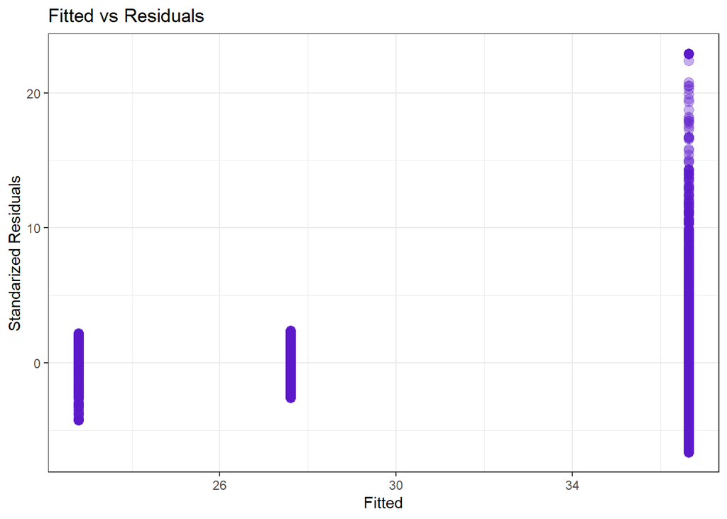

The *QQ (quantile-quantile) plot* did not display the normality of residuals. The residuals did not follow the 45-degree line.

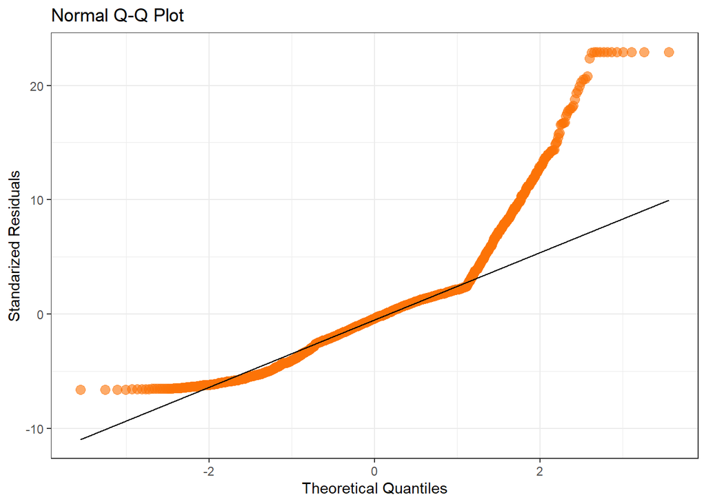

Moreover, a *Boxplot* displayed the distribution of BMI health for each group with significant differences.

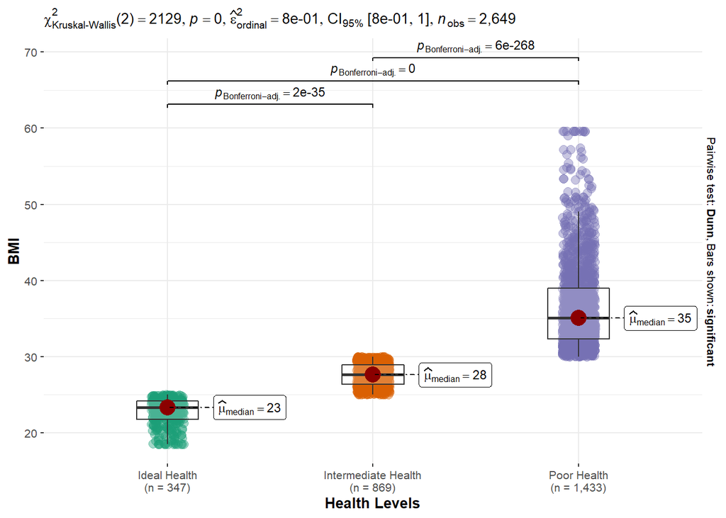

- **3. Equal Variance** - the variances for each group are equal or approximately equal.

Since the p-value < 0.001 was lower than 0.05 level of significance, we did not assume equality of variances.

```
Levene's Test for Homogeneity of Variance (center = median: FALSE)
        Df F value    Pr(>F)
group    2  283.73 < 2.2e-16 ***
      2646
---
Signif. codes:  0 '***' 0.001 '**' 0.01 '*' 0.05 '.' 0.1 ' ' 1
```

### Kruskal-Wallis Test

We used a nonparametric alternative, Kruskal-Wallis, to ANOVA test.

```
    Kruskal-Wallis rank sum test

data:  clean_data$BMI by clean_data$BMI3cat
Kruskal-Wallis chi-squared = 2129.4, df = 2, p-value < 2.2e-16
```

#### Hypothesis:

- $H_0$: $M_{Ideal} = M_{Intermediate} = M_{Poor}$
- $H_1$: at least one group is different

#### Test Statistic

- $H = 2129.4$

#### p-Value

- $p < 0.001$

#### Conclusion

Reject $H_0$ at the $\alpha$=0.05 level. There was sufficient evidence to suggest that there was a difference in BMI between the three levels of health.

### Posthoc Dunn’s Test

Dunn’s test determined which groups were significantly different with comparisons between each independent group.

All groups had significant variance among each other, with a p-value < 0.001 lower than 0.05 level of significance.

```
 Dunn's test of multiple comparisons using rank sums : holm

                                 mean.rank.diff   pval
Intermediate Health-Ideal Health        607.998 <2e-16 ***
Poor Health-Ideal Health               1758.999 <2e-16 ***
Poor Health-Intermediate Health        1151.001 <2e-16 ***
---
Signif. codes:  0 '***' 0.001 '**' 0.01 '*' 0.05 '.' 0.1 ' ' 1
```

**2. Again, consider the sample of data from the JHS. In this problem, we will be examining systolic blood pressure (*sbp*; mmHg) as a function of health as categorized by body mass index (*BMI3cat*; Ideal Health, Intermediate Health, and Poor Health), smoking status (*everSmoker*; 0=never smoker, 1=former or current smoker), and the interaction between health as categorized by body mass index and smoking status.**

```r
blood_data <- data %>%
  select(BMI3cat, sbp, everSmoker) %>%
  drop_na()
```

**a. Find the appropriate summary statistics to summarize the data.**

```r
# mean by BMI and Smoke
smoke_mean <- tapply(blood_data$sbp,
                     INDEX = list(blood_data$BMI3cat, blood_data$everSmoker),
                     FUN = mean)
formattable(as.data.frame(smoke_mean))
```

|  | No | Yes |
| --- | --- | --- |
| Ideal Health | 121.4466 | 127.0254 |
| Intermediate Health | 124.9607 | 126.8340 |
| Poor Health | 126.9812 | 127.1245 |

**b. Use ANOVA to determine if there is a difference in systolic blood pressure between health as categorized by body mass index, smoking status, and the interaction between health as categorized by body mass index and smoking status. Test at the $\alpha=0.05$ level. Remember to remove the interaction term if appropriate to do so.**

```r
# Two-way ANOVA with Interaction
# Null Hypothesis:
# - H1: The means of observations grouped by Health Levels are the same
# - H2: The means of observations grouped by Smoking are the same
# - H3: There is no interaction between Health Levels and Smoking

blood_model <- blood_data$sbp ~ blood_data$BMI3cat * factor(blood_data$everSmoker)
summary(h3_interaction_blood <- aov(blood_model))
```

```
                                                   Df Sum Sq Mean Sq F value
blood_data$BMI3cat                                  2   3619  1809.7   7.546
factor(blood_data$everSmoker)                       1   1300  1300.1   5.421
blood_data$BMI3cat:factor(blood_data$everSmoker)    2   1920   960.1   4.003
Residuals                                        2635 631912   239.8
                                                  Pr(>F)
blood_data$BMI3cat                               0.00054 ***
factor(blood_data$everSmoker)                    0.01997 *
blood_data$BMI3cat:factor(blood_data$everSmoker) 0.01837 *
Residuals
---
Signif. codes:  0 '***' 0.001 '**' 0.01 '*' 0.05 '.' 0.1 ' ' 1
```

### Hypothesis

- $H_0$: There is no interaction between Health levels and Smoking
- $H_1$: There is an interaction between Health Levels and Smoking

### Test Statistic

- $F_{Health-Smoking} = 4.003$

### p-Value

- $p = 0.01837$

## Conclusion

Reject $H_0$ at the $\alpha$=0.05 level. There is sufficient evidence to suggest that there is an interaction between Health Levels (ideal, intermediate, and poor), and Smoking status.

In other words, the relationship between Health Levels depends on the Smoking status. No further testing is required because there is an interaction between Health Levels and Smoking status.

**c. Construct a profile plot to help explain results of part (b).**

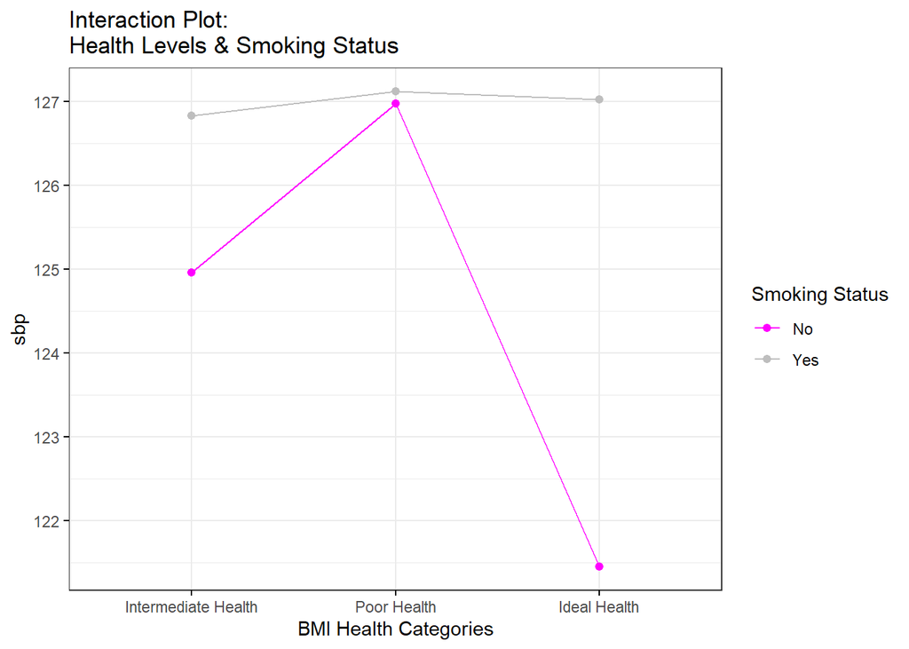

```r
# profile plot using ggline
profile <- ggline(blood_data, x = "BMI3cat", y = "sbp", color = "everSmoker",
       add = "mean",
       show.line.label = FALSE,
       palette = c("magenta", "gray"),
       xlab = "BMI Health Categories",)+
  theme_bw()

interaction_plot <- ggpar(profile,
                      main = "Interaction Plot: \nHealth Levels & Smoking Status",
                      legend.title = "Smoking Status",
                      legend = "right")

interaction_plot
```

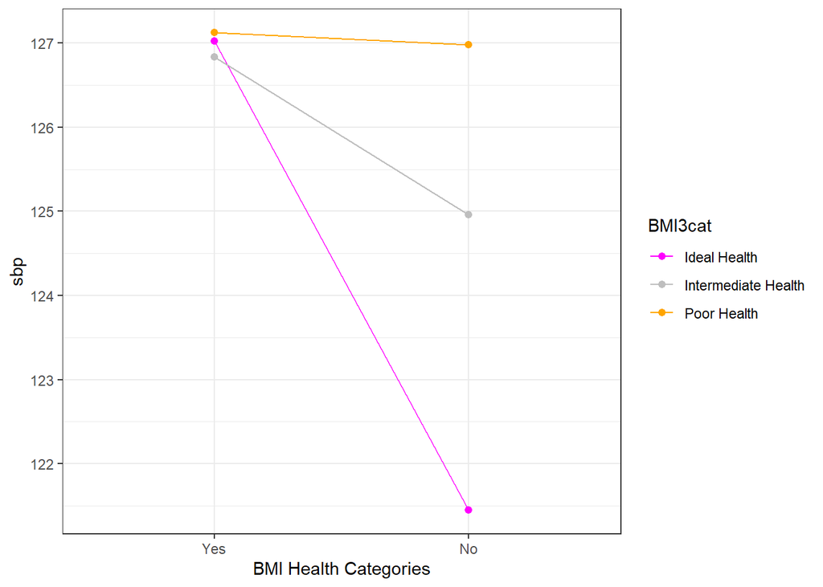

```r
# smoke
# profile plot using ggline
profile_smoke <- ggline(blood_data, x = "everSmoker", y = "sbp", color = "BMI3cat",
       add = "mean",
       show.line.label = FALSE,
       palette = c("magenta", "gray", "orange"),
       xlab = "BMI Health Categories",)+
  theme_bw()
profile_smoke
```

**d. Use the appropriate posthoc test to determine differences in main effects or the interaction term, whichever is appropriate for the results in part (b). Test at the $\alpha=0.05$ level.**

## ANOVA Assumption

### 1. Independece

### 2. Normality

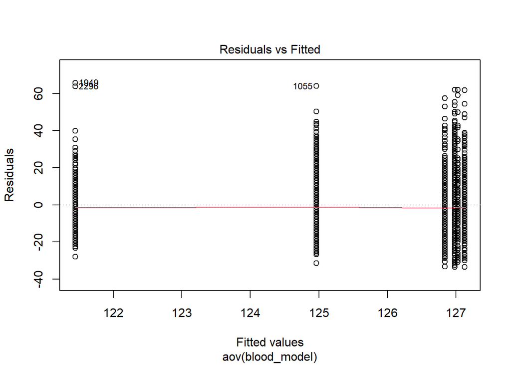

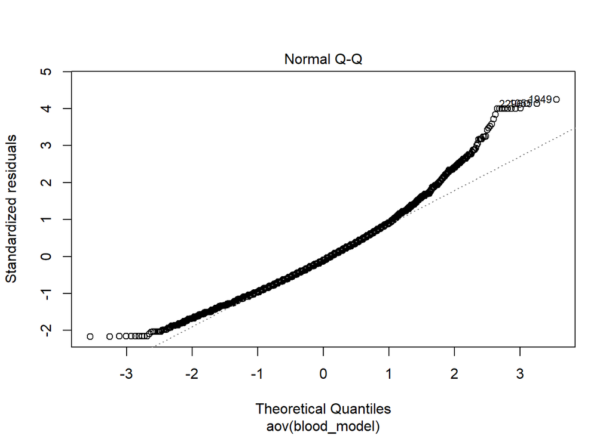

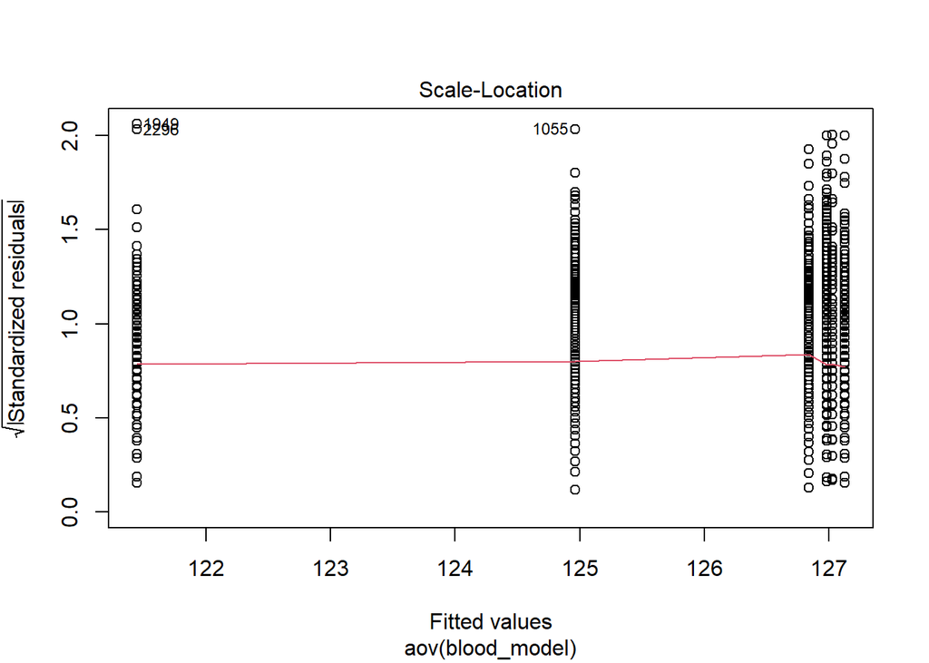

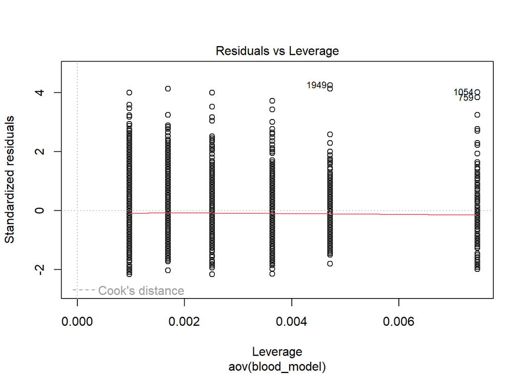

```r
plot(h3_interaction_blood)
```

### 3. Equal Variance

### Levene’s Test for Equality of Variances

```r
LeveneTest(blood_model)
```

```
Levene's Test for Homogeneity of Variance (center = median)
        Df F value  Pr(>F)
group    5   2.486 0.02961 *
      2635
---
Signif. codes:  0 '***' 0.001 '**' 0.01 '*' 0.05 '.' 0.1 ' ' 1
```

Since the p-value is lower than the significance level of 0.05, the ANOVA assumption is invalid.

## Main Effects for BMI Health

```r
kruskal.test(blood_data$sbp ~ blood_data$BMI3cat)
```

```
    Kruskal-Wallis rank sum test

data:  blood_data$sbp by blood_data$BMI3cat
Kruskal-Wallis chi-squared = 19.694, df = 2, p-value = 5.289e-05
```

```r
# kruskalmc(blood_data$sbp ~ blood_data$BMI3cat)
# pairwise.wilcox.test(blood_data$sbp, blood_data$BMI3cat,
#                      p.adjust.method = "bonferroni",
#                      exact = FALSE)
DunnTest(blood_data$sbp ~ blood_data$BMI3cat)
```

```
 Dunn's test of multiple comparisons using rank sums : holm

                                 mean.rank.diff   pval
Intermediate Health-Ideal Health      118.18781 0.0295 *
Poor Health-Ideal Health              194.86712  6e-05 ***
Poor Health-Intermediate Health        76.67931 0.0295 *
---
Signif. codes:  0 '***' 0.001 '**' 0.01 '*' 0.05 '.' 0.1 ' ' 1
```

## Main Effects for Smoking Health

```r
kruskal.test(blood_data$sbp ~ blood_data$everSmoker)
```

```
    Kruskal-Wallis rank sum test

data:  blood_data$sbp by blood_data$everSmoker
Kruskal-Wallis chi-squared = 3.3463, df = 1, p-value = 0.06736
```

```r
# kruskalmc(blood_data$sbp ~ blood_data$everSmoker)
# pairwise.wilcox.test(blood_data$sbp, blood_data$everSmoker,
#                      p.adjust.method = "bonferroni",
#                      exact = FALSE)
DunnTest(blood_data$sbp ~ blood_data$everSmoker)
```

```
 Dunn's test of multiple comparisons using rank sums : holm

       mean.rank.diff   pval
Yes-No       58.91242 0.0674 .
---
Signif. codes:  0 '***' 0.001 '**' 0.01 '*' 0.05 '.' 0.1 ' ' 1
```

**e. Write a brief paragraph describing the results of your analysis. Include summary statistics, results of the hypothesis testing in part (b), results of the posthoc test in part (d), and the profile plot in part (c) to help convey the results.**